# Practical Machine Learning Assignment

Martin Baierl

10/05/2020

## Practical Machine Learning -Prediction Assignment Writeup

R Markdown

# Executive Summary

A random forest machine learning algorithm is trained on data from accelerometers to predict whether participants performed barbell lifts correctly or incorrectly and in which way. The algorithm is then used to predict 20 test cases for which the results have been submitted in the Course Project Prediction Quiz.

# Dataset

Using devices such as Jawbone Up, Nike FuelBand, and Fitbit it is now possible to collect a large amount of data about personal activity relatively inexpensively. These type of devices are part of the quantified self movement – a group of enthusiasts who take measurements about themselves regularly to improve their health, to find patterns in their behavior, or because they are tech geeks. One thing that people regularly do is quantify how much of a particular activity they do, but they rarely quantify how well they do it. In this project, your goal will be to use data from accelerometers on the belt, forearm, arm, and dumbell of 6 participants. They were asked to perform barbell lifts correctly and incorrectly in 5 different ways.

Further details on the dataset used, the Weight Lifting Exercises Dataset, can be found on the following website: http://web.archive.org/web/20161224072740/http:/groupware.les.inf.puc-rio.br/har

The training data for this project are available here: https://d396qusza40orc.cloudfront.net/predmachlearn/pml-training.csv  
The test data are available here: https://d396qusza40orc.cloudfront.net/predmachlearn/pml-testing.csv

# License

The dataset is provided under Creative Commons license (CC BY-SA) by Velloso et al. The following conference paper summarises their work and findings:

Velloso, E.; Bulling, A.; Gellersen, H.; Ugulino, W.; Fuks, H. Qualitative Activity Recognition of Weight Lifting Exercises. Proceedings of 4th International Conference in Cooperation with SIGCHI (Augmented Human ’13) . Stuttgart, Germany: ACM SIGCHI, 2013. http://web.archive.org/web/20170519033209/http://groupware.les.inf.puc-rio.br/public/papers/2013.Velloso.QAR-WLE.pdf

# Required Libraries

The below libraries are required. Model training and prediction is undertaken using the `{r}caret` package.

```r
require(caret)
require(parallel)
require(doParallel)
```

```r
require(corrplot)
require(e1071)
require(ranger)
```

# Getting and Loading the Data

```r
pml_train_url <- "https://d396qusza40orc.cloudfront.net/predmachlearn/pml-training.csv"
pml_test_url <- "https://d396qusza40orc.cloudfront.net/predmachlearn/pml-testing.csv"

pml_train <- read.csv(url(pml_train_url))
pml_test <- read.csv(url(pml_test_url))

dim(pml_train)
```

```
## [1] 19622   160
```

```r
dim(pml_test)
```

```
## [1]  20 160
```

The training dataset contains 19622 observations for 160 variables, whereas for 20 observations in the test set, the “classe” variable, representing the way the barbell lifting is performed, is to be predicted.

# Data Cleaning

A number of variables appear to refer to the participant, time and window and can therefore be discarded from the set of predictive variables.

```r
pml_train <- pml_train[, !(grepl("^X|timestamp|window|user", names(pml_train)))]
pml_test  <- pml_test[, !(grepl("^X|timestamp|window|user", names(pml_test)))]
```

In addition, several variables contain mostly NA values bringing little predictive value and can also be removed, in addition leaving variables only containing NA in the test data causes problems when predicting classe.

```r
col.na.train <- colSums(sapply(pml_train, is.na))
col.na.test <- colSums(sapply(pml_test, is.na))

pml_train <- pml_train[,col.na.train == 0 & col.na.test == 0]
pml_test <- pml_test[,col.na.train == 0 & col.na.test == 0]
```

Finally, factor variables in the dataset are converted into numeric variables (with the exception of the Classe variable) and the variable `{r}problem_id` is removed from the test set.

```r
classe <- pml_train$classe
colnames_train <- colnames(pml_train)
pml_train[colnames_train]  <- sapply(pml_train, as.numeric)
pml_train$classe <- classe
colnames_test <- colnames(pml_test)
pml_test[colnames_test]   <- sapply(pml_test, as.numeric)
pml_test$problem_id <- NULL
dim(pml_train)
```

```
## [1] 19622    53
```

```r
dim(pml_test)
```

```
## [1] 20 52
```

# Exploratory Data Analysis

A first step in exploring the data is to identify potential correlations between variables, which is done using `{r} corrplot`. Positive correlations are displayed in blue and negative correlations in red color. Color intensity and the size of the circle are proportional to the correlation coefficients.

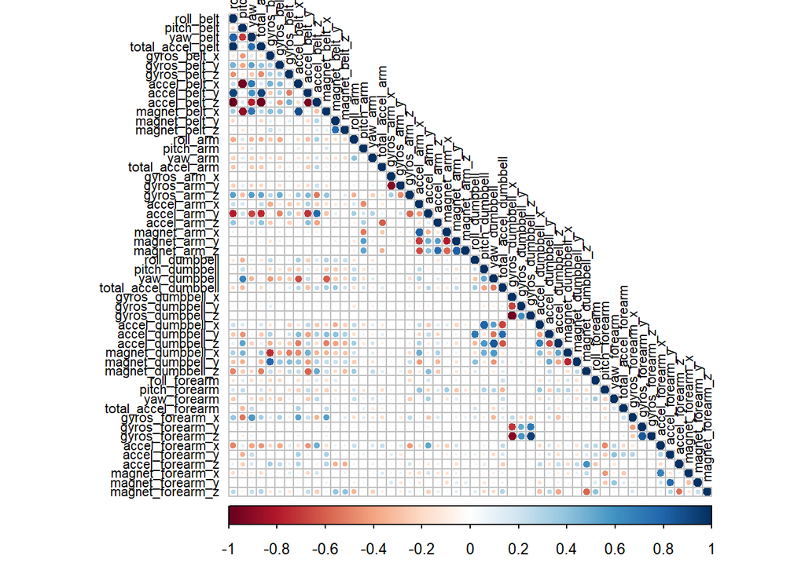

```r
cor_mat <- cor(pml_train[-53])
corrplot(cor_mat, method = "circle", type = "lower", tl.cex = 0.7, tl.col = rgb(0,0,0))
```

# Modelling

Prior to any modelling, the dataset needs to be split into a training (75%) and testing (25%) set using the `{r}createDataPartition()` function from the caret package. The training set is used to ‘train’ the model and the testing set will be used for validation and to asses the out of sample performance.

```r
inTrain   <- createDataPartition(pml_train$classe, p=0.75, list=F)
trainData <- pml_train[inTrain, ]
testData  <- pml_train[-inTrain, ]
```

```r
set.seed(1234)

cluster <- makeCluster(detectCores() - 1)
registerDoParallel(cluster)

fitRf <- train(classe ~ ., data=trainData, method="rf", trControl=trainControl(method="cv", 7, allowParallel = TRUE), ntree=250)
fitRf
```

```
## Random Forest
##
## 14718 samples
##    52 predictor
##     5 classes: 'A', 'B', 'C', 'D', 'E'
##
## No pre-processing
## Resampling: Cross-Validated (7 fold)
## Summary of sample sizes: 12615, 12616, 12614, 12617, 12614, 12616, ...
## Resampling results across tuning parameters:
##
##   mtry  Accuracy   Kappa
##    2    0.9914388  0.9891702
##   27    0.9915070  0.9892561
##   52    0.9843728  0.9802306
##
## Accuracy was used to select the optimal model using the largest value.
## The final value used for the model was mtry = 27.
```

```r
stopCluster(cluster)
registerDoSEQ()
```

The trained random forest algorithm is then used with `{r}predict()` to predict the classe of the observations in the test set. `{r}confusionMatrix()` summarises the results and assess the model accuracy:

```r
predictRf <- predict.train(fitRf, testData)
confusionMatrix(testData$classe, predictRf)
```

```
## Confusion Matrix and Statistics
##
##           Reference
## Prediction    A    B    C    D    E
##          A 1395    0    0    0    0
##          B    4  941    4    0    0
##          C    0    5  848    2    0
##          D    0    1   15  788    0
##          E    0    0    0    7  894
##
## Overall Statistics
##
##                Accuracy : 0.9923
##                  95% CI : (0.9894, 0.9945)
##     No Information Rate : 0.2853
##     P-Value [Acc > NIR] : < 2.2e-16
##
##                   Kappa : 0.9902
##
##  Mcnemar's Test P-Value : NA
##
## Statistics by Class:
##
##                      Class: A Class: B Class: C Class: D Class: E
## Sensitivity            0.9971   0.9937   0.9781   0.9887   1.0000
## Specificity            1.0000   0.9980   0.9983   0.9961   0.9983
## Pos Pred Value         1.0000   0.9916   0.9918   0.9801   0.9922
## Neg Pred Value         0.9989   0.9985   0.9953   0.9978   1.0000
## Prevalence             0.2853   0.1931   0.1768   0.1625   0.1823
## Detection Rate         0.2845   0.1919   0.1729   0.1607   0.1823
## Detection Prevalence   0.2845   0.1935   0.1743   0.1639   0.1837
## Balanced Accuracy      0.9986   0.9958   0.9882   0.9924   0.9991
```

The predicted classes for the 20 observations in the test set are shown below:

```r
result <- predict.train(fitRf, pml_test)
result
```

```
##  [1] B A B A A E D B A A B C B A E E A B B B
## Levels: A B C D E
```